# Predicting Barbell Lift Techniques Using Random Forest

Sujeeth R K

October 29, 2025

The random forest algorithm from the randomForest R package was selected to build this classifier. This choice was particularly suitable given the time constraints and the inherent non-linearity present in the dataset. Random forest offers significant benefits, including minimal parameter tuning requirements while delivering strong performance and straightforward implementation.

Key stages in the model development process:

1. Remove timestamp-related columns from both training and validation datasets.
2. Drop columns containing a high proportion of missing values from both datasets.
3. Exclude columns exhibiting nearly zero variance from both datasets.
4. Split the training dataset into training and testing subsets (for cross-validation purposes).
5. Build a random forest classifier on the training subset using variable importance metrics.
6. Evaluate model performance on the testing subset.
7. Generate and save predictions for the validation dataset.

Now let's walk through the implementation.

Loading required libraries

```r
library(caret)
library(ggplot2)
library(randomForest)
```

The training dataset contained numerous columns with missing or NA values. Proper identification of NA values was critical for data preprocessing. The following code loads both training and validation datasets from their respective CSV files.

```r
data = read.table("pml-training.csv", sep=",", header = TRUE, na.strings=c("","NA","#DIV/0!"))
validation_data = read.table("pml-testing.csv", sep=",", header = TRUE, na.strings=c("","NA"
,"#DIV/0!"))
```

After loading the data, timestamp-associated columns were excluded. These features don't contribute meaningful information for predicting the output class and pose challenges during processing.

```r
#removing timestamp columns
data <- data[,c(-1,-3,-4,-5)]
validation_data <- validation_data[,c(-1,-3,-4,-5)]
```

Several columns in the training dataset contained more than 95% NA values, while the remaining columns had complete data. Additionally, these sparse columns were redundant (being derivatives of other features) and offered limited predictive value. Therefore, they were also removed from the dataset.

```r
#removing cols with only NA values
ret <- removeColsWithNAs(data)
data <- ret$a
validation_data <- validation_data[,ret$b]
```

This preprocessing step successfully reduced the predictor count from 156 to 56. The subsequent step involves removing features with minimal variance.

```r
#removing predictors with zero variance
nzv <- nearZeroVar(data)
data <- data[,-nzv]
validation_data <- validation_data[,-nzv]
```

Dividing the training dataset into training and testing subsets.

```r
set.seed(1729)
#partition train data into training and testing data
inTrain = createDataPartition(y = data$classe, p = 0.7, list = FALSE)
training = data[inTrain, ]
testing = data[-inTrain, ]
```

Plot of yaw_belt vs num_window in training set:

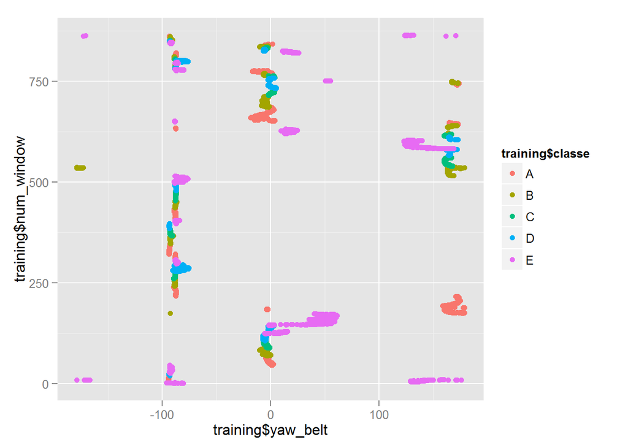

The above plot shows the non-linearity of the classification problem.

Plot of mTry vs Out-Of-Bag-Error (for 501 trees):

```
## mtry = 7  OOB error = 0.41%
## Searching left ...
## mtry = 4     OOB error = 0.58%
## -0.386 0.05
## Searching right ...
## mtry = 14    OOB error = 0.29%
## 0.2982 0.05
## mtry = 28    OOB error = 0.26%
## 0.1 0.05
## mtry = 54    OOB error = 0.38%
## -0.4444 0.05
```

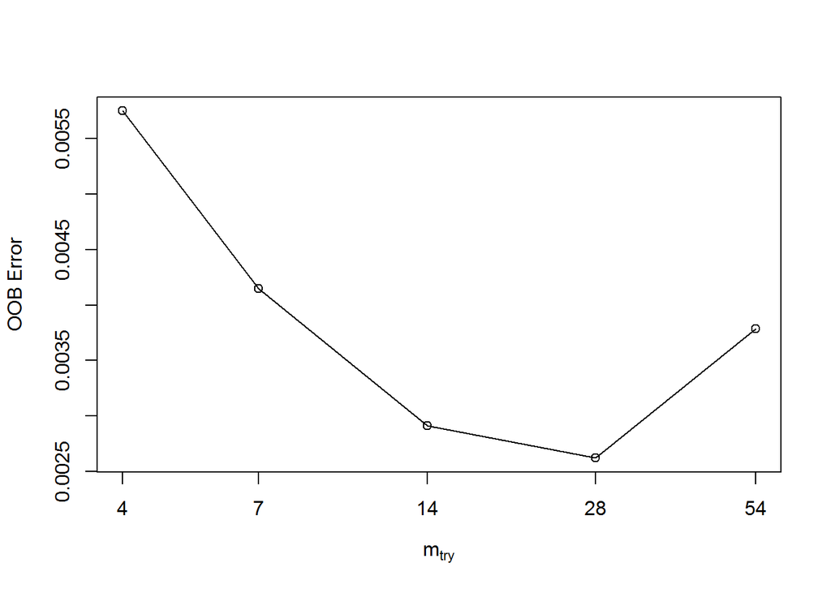

```
##        mtry OOBError
## 4.OOB     4 0.005751
## 7.OOB     7 0.004149
## 14.OOB   14 0.002912
## 28.OOB   28 0.002621
## 54.OOB   54 0.003785
```

```r
#Training a randomForest model
#finding optimal value for mTry parameter
tuneRF(training[,-55], training[,55], nTryTree = 501, plot = TRUE)
```

Dimensionality reduction using PCA was avoided since it was too time-consuming on such a large data.

Fitting the model to train data and predicting on test data

```r
set.seed(223)
model <- randomForest(classe ~ ., data = training, importance = TRUE, ntree = 501)
pred <- predict(model, newdata = testing)
```

Plot of variables vs overall importance:

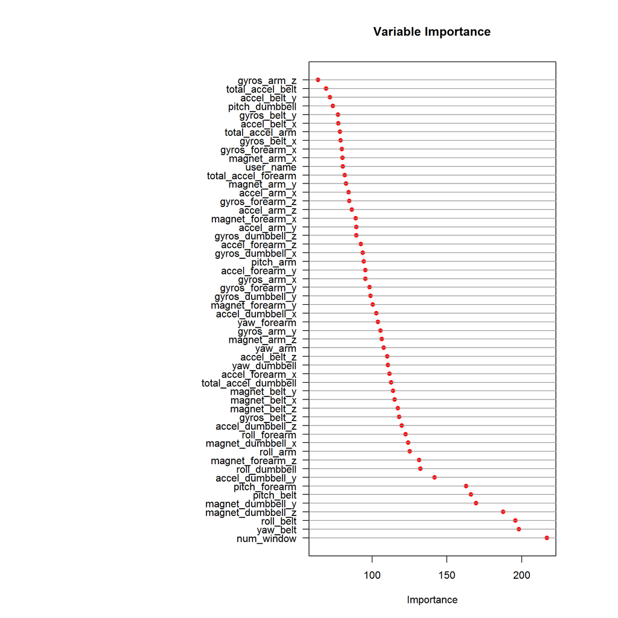

Confusion Matrix for predictions on test data

```
##
## pred    A    B    C    D    E
##    A 1673    1    0    0    0
##    B    1 1138    7    0    0
##    C    0    0 1019    8    0
##    D    0    0    0  955    4
##    E    0    0    0    1 1078
```

Overall accuracy and classwise accuracy

```
## Overall Accuracy =  0.9963
```

```
## Accuracy for class  A  =  0.9994
## Accuracy for class  B  =  0.993
## Accuracy for class  C  =  0.9922
## Accuracy for class  D  =  0.9958
## Accuracy for class  E  =  0.9991
```

Information summary on trained model

```
##
## Call:
##  randomForest(formula = classe ~ ., data = training, importance = TRUE,      ntree = 501)
##                Type of random forest: classification
##                      Number of trees: 501
## No. of variables tried at each split: 7
##
##         OOB estimate of  error rate: 0.22%
## Confusion matrix:
##      A    B    C    D    E class.error
## A 3906    0    0    0    0    0.000000
## B    6 2651    1    0    0    0.002634
## C    0    3 2392    1    0    0.001669
## D    0    0   11 2239    2    0.005773
## E    0    0    0    6 2519    0.002376
```

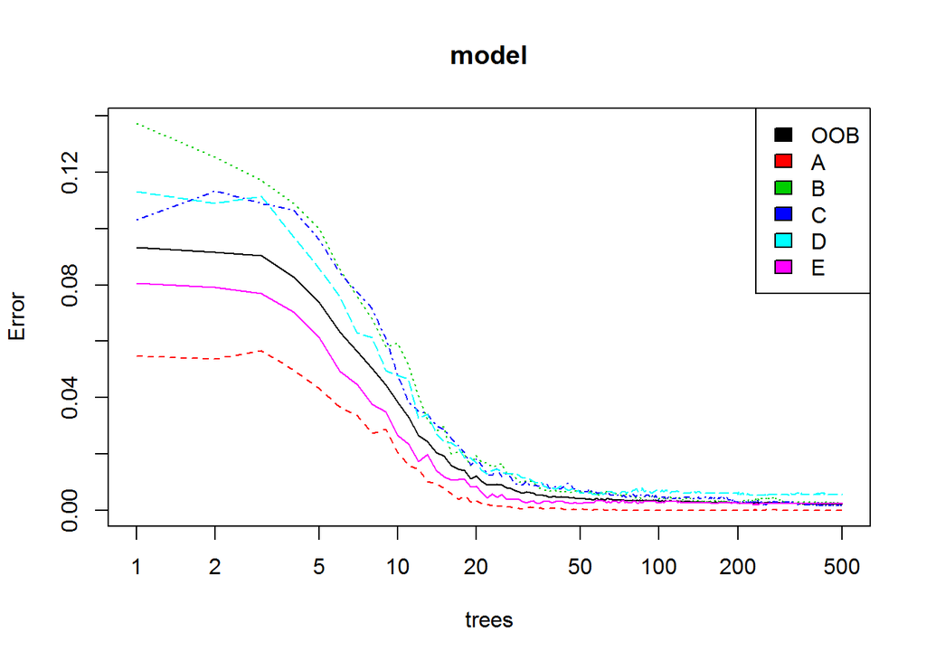

```r
plot(model, log = "x")
legend("topright", colnames(model$err.rate), col=1:6, fill=1:6)
```

Predictions output on validation data

```r
pred <- predict(model, newdata = validation_data)
pred
```

```
##  1  2  3  4  5  6  7  8  9 10 11 12 13 14 15 16 17 18 19 20
##  B  A  B  A  A  E  D  B  A  A  B  C  B  A  E  E  A  B  B  B
## Levels: A B C D E
```